# NYC_property_sales_EDA

## HW2 (answer key)

### [NYC property sales](https://www.kaggle.com/new-york-city/nyc-property-sales) : EDA

Instructor: [Pedram Jahangiry](https://github.com/PJalgotrader)

```python
import numpy as np
import pandas as pd
import matplotlib.pyplot as plt
import seaborn as sns
import statsmodels.api as sm

sns.set()
```

```python
rand_state=1000
```

```python
df = pd.read_csv("nyc-rolling-sales.csv")
df_raw = df
df.head()
```

|  | Unnamed: 0 | BOROUGH | NEIGHBORHOOD | BUILDING CLASS CATEGORY | TAX CLASS AT PRESENT | BLOCK | LOT | EASE-MENT | BUILDING CLASS AT PRESENT | ADDRESS | ... | RESIDENTIAL UNITS | COMMERCIAL UNITS | TOTAL UNITS | LAND SQUARE FEET | GROSS SQUARE FEET | YEAR BUILT | TAX CLASS AT TIME OF SALE | BUILDING CLASS AT TIME OF SALE | SALE PRICE | SALE DATE |
| --- | --- | --- | --- | --- | --- | --- | --- | --- | --- | --- | --- | --- | --- | --- | --- | --- | --- | --- | --- | --- | --- |
| 0 | 4 | 1 | ALPHABET CITY | 07 RENTALS - WALKUP APARTMENTS | 2A | 392 | 6 |  | C2 | 153 AVENUE B | ... | 5 | 0 | 5 | 1633 | 6440 | 1900 | 2 | C2 | 6625000 | 2017-07-19 00:00:00 |
| 1 | 5 | 1 | ALPHABET CITY | 07 RENTALS - WALKUP APARTMENTS | 2 | 399 | 26 |  | C7 | 234 EAST 4TH STREET | ... | 28 | 3 | 31 | 4616 | 18690 | 1900 | 2 | C7 | - | 2016-12-14 00:00:00 |
| 2 | 6 | 1 | ALPHABET CITY | 07 RENTALS - WALKUP APARTMENTS | 2 | 399 | 39 |  | C7 | 197 EAST 3RD STREET | ... | 16 | 1 | 17 | 2212 | 7803 | 1900 | 2 | C7 | - | 2016-12-09 00:00:00 |
| 3 | 7 | 1 | ALPHABET CITY | 07 RENTALS - WALKUP APARTMENTS | 2B | 402 | 21 |  | C4 | 154 EAST 7TH STREET | ... | 10 | 0 | 10 | 2272 | 6794 | 1913 | 2 | C4 | 3936272 | 2016-09-23 00:00:00 |
| 4 | 8 | 1 | ALPHABET CITY | 07 RENTALS - WALKUP APARTMENTS | 2A | 404 | 55 |  | C2 | 301 EAST 10TH STREET | ... | 6 | 0 | 6 | 2369 | 4615 | 1900 | 2 | C2 | 8000000 | 2016-11-17 00:00:00 |

5 rows × 22 columns

```python
df.info()
```

```
<class 'pandas.core.frame.DataFrame'>
RangeIndex: 84548 entries, 0 to 84547
Data columns (total 22 columns):
Unnamed: 0                        84548 non-null int64
BOROUGH                           84548 non-null int64
NEIGHBORHOOD                      84548 non-null object
BUILDING CLASS CATEGORY           84548 non-null object
TAX CLASS AT PRESENT              84548 non-null object
BLOCK                             84548 non-null int64
LOT                               84548 non-null int64
EASE-MENT                         84548 non-null object
BUILDING CLASS AT PRESENT         84548 non-null object
ADDRESS                           84548 non-null object
APARTMENT NUMBER                  84548 non-null object
ZIP CODE                          84548 non-null int64
RESIDENTIAL UNITS                 84548 non-null int64
COMMERCIAL UNITS                  84548 non-null int64
TOTAL UNITS                       84548 non-null int64
LAND SQUARE FEET                  84548 non-null object
GROSS SQUARE FEET                 84548 non-null object
YEAR BUILT                        84548 non-null int64
TAX CLASS AT TIME OF SALE         84548 non-null int64
BUILDING CLASS AT TIME OF SALE    84548 non-null object
SALE PRICE                        84548 non-null object
SALE DATE                         84548 non-null object
dtypes: int64(10), object(12)
memory usage: 14.2+ MB
```

```python
# First Let's remove  irrelavant columns:
df.drop(["Unnamed: 0"], axis=1, inplace=True)
```

```python
# Now let's figure out what should be the type of variables:

for col in df.columns:
   # if df[col].dtype=="object":
        print(col, df[col].nunique())
```

```
BOROUGH 5
NEIGHBORHOOD 254
BUILDING CLASS CATEGORY 47
TAX CLASS AT PRESENT 11
BLOCK 11566
LOT 2627
EASE-MENT 1
BUILDING CLASS AT PRESENT 167
ADDRESS 67563
APARTMENT NUMBER 3989
ZIP CODE 186
RESIDENTIAL UNITS 176
COMMERCIAL UNITS 55
TOTAL UNITS 192
LAND SQUARE FEET 6062
GROSS SQUARE FEET 5691
YEAR BUILT 158
TAX CLASS AT TIME OF SALE 4
BUILDING CLASS AT TIME OF SALE 166
SALE PRICE 10008
SALE DATE 364
```

### Exploring the variables:

1. **BOROUGH**: A digit code for the borough the property is located in; in order these are Manhattan (1), Bronx (2), Brooklyn (3), Queens (4), and Staten Island (5). **This variable should be a categorical variable**
2. **NEIGHBORHOOD**: Department of Finance assessors determine the neighborhood name in the course of valuing properties. The common name of the neighborhood is generally the same as the name Finance designates. However, there may be slight differences in neighborhood boundary lines and some sub-neighborhoods may not be included. **This variable should be categorical.**
3. **BUILDING CLASS CATEGORY**: This is a field that we are including so that users of the Rolling Sales Files can easily identify similar properties by broad usage (e.g. One Family Homes) without looking up individual Building Classes. Files are sorted by Borough, Neighborhood, Building Class Category, Block and Lot. **This variable should be categorical.**
4. **TAX CLASS AT PRESENT** Every property in the city is assigned to one of four tax classes (Classes 1, 2, 3, and 4), based on the use of the property. **This variable should be categorical.**
- Class 1: Includes most residential property of up to three units (such as one-, two-, and three-family homes and small stores or offices with one or two attached apartments), vacant land that is zoned for residential use, and most condominiums that are not more than three stories.
- Class 2: Includes all other property that is primarily residential, such as cooperatives and condominiums.
- Class 3: Includes property with equipment owned by a gas, telephone or electric company.
- Class 4: Includes all other properties not included in class 1,2, and 3, such as offices, factories, warehouses, garage buildings, etc.
1. **BLOCK** and **LOT**: A Tax Block is a sub-division of the borough on which real properties are located. The Department of Finance uses a Borough-Block-Lot classification to label all real property in the City. “Whereas” addresses describe the street location of a property, the block and lot distinguishes one unit of real property from another, such as the different condominiums in a single building. Also, block and lots are not subject to name changes based on which side of the parcel the building puts its entrance on. A Tax Lot is a subdivision of a Tax Block and represents the property unique location. **Because there are more than 11k unique blocks in the dataset, it doesn't make sense to define it as a categorical variable! Will leave it as numerical. The same story for LOT**
2. **BUILDING CLASS AT PRESENT**: The Building Classification is used to describe a property’s constructive use. The first position of the Building Class is a letter that is used to describe a general class of properties (for example “A” signifies one-family homes, “O” signifies office buildings. “R” signifies condominiums). The second position, a number, adds more specific information about the property’s use or construction style (using our previous examples “A0” is a Cape Cod style one family home, “O4” is a tower type office building and “R5” is a commercial condominium unit). The term Building Class used by the Department of Finance is interchangeable with the term Building Code used by the Department of Buildings. **This variable should be categorical.**
1. **ADDRESS**: The street address of the property as listed on the Sales File. Coop sales include the apartment number in the address field. **We are not going to extract any information from the address in this course!**
2. **ZIP CODE**: The property’s postal code. **This variable should be categorical.**
3. **RESIDENTIAL UNITS** : The number of residential units at the listed property. **This variable should be numeric**
4. **COMMERCIAL UNITS** :The number of commercial units at the listed property. **This variable should be numeric**
5. **TOTAL UNITS** :The total number of units at the listed property. **This variable should be numeric**
6. **LAND SQUARE FEET** : The land area of the property listed in square feet. **This variable should be numeric**
7. **GROSS SQUARE FEET** : The total area of all the floors of a building as measured from the exterior surfaces of the outside walls of the building, including the land area and space within any building or structure on the property. **This variable should be numeric**
1. **YEAR BUILT** : Year the structure on the property was built. **This variable should be categorical**
2. **TAX CLASS AT TIME OF SALE** and **BUILDING CLASS AT TIME OF SALE**. Both of these variables should be **categorical**.
3. **SALE PRICE** : This variable should be **numeric.**
4. **SALE DATE** : This variable should be **data time.** However, we can save the "year" or "month" part as a new categorical variable.
5. **EASEMENT**: An easement is a right, such as a right of way, which allows an entity to make limited use of another’s real property. For example: MTA railroad tracks that run across a portion of another property.

Note: **0 Dollar Sales Price**: A 0 dollar sale indicates that there was a transfer of ownership without a cash consideration. There can be a number of reasons for a 0 dollar sale including transfers of ownership from parents to children. **We will remove all of these observations**

```python
# constructing the date time variable

df['SALE DATE']= pd.to_datetime(df['SALE DATE'], errors='coerce')
```

```python
pd.DatetimeIndex(df['SALE DATE']).year
```

```
Int64Index([2017, 2016, 2016, 2016, 2016, 2017, 2016, 2017, 2017, 2016,
            ...
            2017, 2016, 2016, 2016, 2016, 2016, 2017, 2017, 2016, 2016],
           dtype='int64', name='SALE DATE', length=84548)
```

```python
df['sale_year'] = pd.DatetimeIndex(df['SALE DATE']).year.astype("category")
df['sale_month'] = pd.DatetimeIndex(df['SALE DATE']).month.astype("category")
pd.crosstab(df['sale_month'],df['sale_year'])
```

| sale_year sale_month | 2016 | 2017 |
| --- | --- | --- |
| 1 | 0 | 6871 |
| 2 | 0 | 6323 |
| 3 | 0 | 7705 |
| 4 | 0 | 6402 |
| 5 | 0 | 7461 |
| 6 | 0 | 8293 |
| 7 | 0 | 6319 |
| 8 | 0 | 5681 |
| 9 | 7779 | 0 |
| 10 | 6751 | 0 |
| 11 | 7072 | 0 |
| 12 | 7891 | 0 |

```python
# constructing the numerical variables:
numeric = ["RESIDENTIAL UNITS","COMMERCIAL UNITS","TOTAL UNITS", "LAND SQUARE FEET" , "GROSS SQUARE FEET","SALE PRICE" ]

for col in numeric:
    df[col] = pd.to_numeric(df[col], errors='coerce') # coercing errors to NAs
```

```python
# constructing the categorical variables:
categorical = ["BOROUGH","NEIGHBORHOOD",'BUILDING CLASS CATEGORY', 'TAX CLASS AT PRESENT', 'BUILDING CLASS AT PRESENT','ZIP CODE', 'YEAR BUILT', 'BUILDING CLASS AT TIME OF SALE', 'TAX CLASS AT TIME OF SALE']

for col in categorical:
    df[col] = df[col].astype("category")
```

```python
df.info()
```

```
<class 'pandas.core.frame.DataFrame'>
RangeIndex: 84548 entries, 0 to 84547
Data columns (total 23 columns):
BOROUGH                           84548 non-null category
NEIGHBORHOOD                      84548 non-null category
BUILDING CLASS CATEGORY           84548 non-null category
TAX CLASS AT PRESENT              84548 non-null category
BLOCK                             84548 non-null int64
LOT                               84548 non-null int64
EASE-MENT                         84548 non-null object
BUILDING CLASS AT PRESENT         84548 non-null category
ADDRESS                           84548 non-null object
APARTMENT NUMBER                  84548 non-null object
ZIP CODE                          84548 non-null category
RESIDENTIAL UNITS                 84548 non-null int64
COMMERCIAL UNITS                  84548 non-null int64
TOTAL UNITS                       84548 non-null int64
LAND SQUARE FEET                  58296 non-null float64
GROSS SQUARE FEET                 56936 non-null float64
YEAR BUILT                        84548 non-null category
TAX CLASS AT TIME OF SALE         84548 non-null category
BUILDING CLASS AT TIME OF SALE    84548 non-null category
SALE PRICE                        69987 non-null float64
SALE DATE                         84548 non-null datetime64[ns]
sale_year                         84548 non-null category
sale_month                        84548 non-null category
dtypes: category(11), datetime64[ns](1), float64(3), int64(5), object(3)
memory usage: 9.1+ MB
```

```python
df.isna().sum()
```

```
BOROUGH                               0
NEIGHBORHOOD                          0
BUILDING CLASS CATEGORY               0
TAX CLASS AT PRESENT                  0
BLOCK                                 0
LOT                                   0
EASE-MENT                             0
BUILDING CLASS AT PRESENT             0
ADDRESS                               0
APARTMENT NUMBER                      0
ZIP CODE                              0
RESIDENTIAL UNITS                     0
COMMERCIAL UNITS                      0
TOTAL UNITS                           0
LAND SQUARE FEET                  26252
GROSS SQUARE FEET                 27612
YEAR BUILT                            0
TAX CLASS AT TIME OF SALE             0
BUILDING CLASS AT TIME OF SALE        0
SALE PRICE                        14561
SALE DATE                             0
sale_year                             0
sale_month                            0
dtype: int64
```

**So far, we have identified the NA values. But what about the black cells?**

Let's see if there are any **black** cells?

```python
df.replace(' ',np.nan, inplace=True)
```

```python
df.isna().sum()
```

```
BOROUGH                               0
NEIGHBORHOOD                          0
BUILDING CLASS CATEGORY               0
TAX CLASS AT PRESENT                738
BLOCK                                 0
LOT                                   0
EASE-MENT                         84548
BUILDING CLASS AT PRESENT           738
ADDRESS                               0
APARTMENT NUMBER                  65496
ZIP CODE                              0
RESIDENTIAL UNITS                     0
COMMERCIAL UNITS                      0
TOTAL UNITS                           0
LAND SQUARE FEET                  26252
GROSS SQUARE FEET                 27612
YEAR BUILT                            0
TAX CLASS AT TIME OF SALE             0
BUILDING CLASS AT TIME OF SALE        0
SALE PRICE                        14561
SALE DATE                             0
sale_year                             0
sale_month                            0
dtype: int64
```

```python
df.isna().sum()/len(df) *100
```

```
BOROUGH                             0.000000
NEIGHBORHOOD                        0.000000
BUILDING CLASS CATEGORY             0.000000
TAX CLASS AT PRESENT                0.872877
BLOCK                               0.000000
LOT                                 0.000000
EASE-MENT                         100.000000
BUILDING CLASS AT PRESENT           0.872877
ADDRESS                             0.000000
APARTMENT NUMBER                   77.466055
ZIP CODE                            0.000000
RESIDENTIAL UNITS                   0.000000
COMMERCIAL UNITS                    0.000000
TOTAL UNITS                         0.000000
LAND SQUARE FEET                   31.049818
GROSS SQUARE FEET                  32.658372
YEAR BUILT                          0.000000
TAX CLASS AT TIME OF SALE           0.000000
BUILDING CLASS AT TIME OF SALE      0.000000
SALE PRICE                         17.222170
SALE DATE                           0.000000
sale_year                           0.000000
sale_month                          0.000000
dtype: float64
```

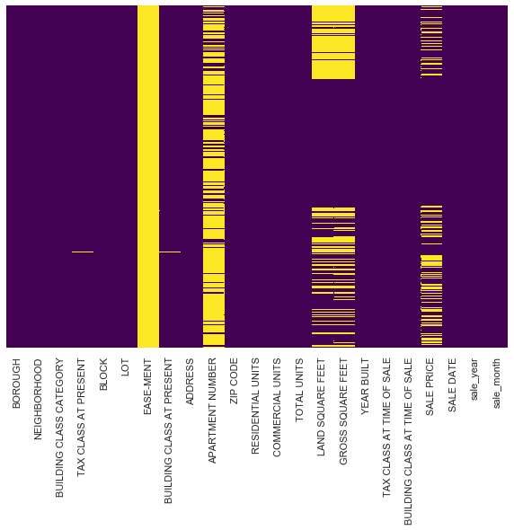

```python
plt.figure(figsize=(10,7))
sns.heatmap(df.isnull(),yticklabels=False,cbar=False,cmap='viridis')
```

### Now let's get rid of the columns with many NAs.

```python
df.drop(["EASE-MENT","APARTMENT NUMBER"], axis=1, inplace=True)
```

```python
# What should we do with the LAND and GROSS sqrf? there are more than 30% of missing data here! One way is to get rid of all the NAs.
# but this is not the best solution. What is your solution?

df=df.dropna()
```

```python
df.isna().sum()
```

```
BOROUGH                           0
NEIGHBORHOOD                      0
BUILDING CLASS CATEGORY           0
TAX CLASS AT PRESENT              0
BLOCK                             0
LOT                               0
BUILDING CLASS AT PRESENT         0
ADDRESS                           0
ZIP CODE                          0
RESIDENTIAL UNITS                 0
COMMERCIAL UNITS                  0
TOTAL UNITS                       0
LAND SQUARE FEET                  0
GROSS SQUARE FEET                 0
YEAR BUILT                        0
TAX CLASS AT TIME OF SALE         0
BUILDING CLASS AT TIME OF SALE    0
SALE PRICE                        0
SALE DATE                         0
sale_year                         0
sale_month                        0
dtype: int64
```

```python
# finally check if there is any duplicated value:
sum(df.duplicated())
```

```
348
```

```python
df.drop_duplicates(inplace=True)
```

### Exercise: Why do we have to remove the duplicated observations? What will happen to R-square? what about the significancy of coefficients?

### Looking for strange observations:

Trick: First lets try to convert all the variables into numeric and look at the description.

```python
temp = df.copy()
```

```python
for cols in temp.columns:
    temp[cols]=pd.to_numeric(temp[cols], errors='coerce')
```

```python
temp.info()
```

```
<class 'pandas.core.frame.DataFrame'>
Int64Index: 47544 entries, 0 to 84547
Data columns (total 21 columns):
BOROUGH                           47544 non-null int64
NEIGHBORHOOD                      0 non-null float64
BUILDING CLASS CATEGORY           0 non-null float64
TAX CLASS AT PRESENT              42401 non-null float64
BLOCK                             47544 non-null int64
LOT                               47544 non-null int64
BUILDING CLASS AT PRESENT         0 non-null float64
ADDRESS                           0 non-null float64
ZIP CODE                          47544 non-null int64
RESIDENTIAL UNITS                 47544 non-null int64
COMMERCIAL UNITS                  47544 non-null int64
TOTAL UNITS                       47544 non-null int64
LAND SQUARE FEET                  47544 non-null float64
GROSS SQUARE FEET                 47544 non-null float64
YEAR BUILT                        47544 non-null int64
TAX CLASS AT TIME OF SALE         47544 non-null int64
BUILDING CLASS AT TIME OF SALE    0 non-null float64
SALE PRICE                        47544 non-null float64
SALE DATE                         47544 non-null int64
sale_year                         47544 non-null int64
sale_month                        47544 non-null int64
dtypes: float64(9), int64(12)
memory usage: 8.0 MB
```

```python
temp.describe().T
```

|  | count | mean | std | min | 25% | 50% | 75% | max |
| --- | --- | --- | --- | --- | --- | --- | --- | --- |
| BOROUGH | 47544.0 | 3.256836e+00 | 9.049520e-01 | 1.000000e+00 | 3.000000e+00 | 3.000000e+00 | 4.000000e+00 | 5.000000e+00 |
| NEIGHBORHOOD | 0.0 | NaN | NaN | NaN | NaN | NaN | NaN | NaN |
| BUILDING CLASS CATEGORY | 0.0 | NaN | NaN | NaN | NaN | NaN | NaN | NaN |
| TAX CLASS AT PRESENT | 42401.0 | 1.428646e+00 | 8.524710e-01 | 1.000000e+00 | 1.000000e+00 | 1.000000e+00 | 2.000000e+00 | 4.000000e+00 |
| BLOCK | 47544.0 | 4.993789e+03 | 3.431769e+03 | 1.000000e+00 | 2.218000e+03 | 4.666000e+03 | 6.983750e+03 | 1.631900e+04 |
| LOT | 47544.0 | 2.278511e+02 | 4.906937e+02 | 1.000000e+00 | 2.100000e+01 | 4.500000e+01 | 9.000000e+01 | 9.009000e+03 |
| BUILDING CLASS AT PRESENT | 0.0 | NaN | NaN | NaN | NaN | NaN | NaN | NaN |
| ADDRESS | 0.0 | NaN | NaN | NaN | NaN | NaN | NaN | NaN |
| ZIP CODE | 47544.0 | 1.098669e+04 | 8.016274e+02 | 0.000000e+00 | 1.047000e+04 | 1.121700e+04 | 1.123800e+04 | 1.169400e+04 |
| RESIDENTIAL UNITS | 47544.0 | 2.553656e+00 | 1.723198e+01 | 0.000000e+00 | 1.000000e+00 | 1.000000e+00 | 2.000000e+00 | 1.844000e+03 |
| COMMERCIAL UNITS | 47544.0 | 2.392310e-01 | 1.088558e+01 | 0.000000e+00 | 0.000000e+00 | 0.000000e+00 | 0.000000e+00 | 2.261000e+03 |
| TOTAL UNITS | 47544.0 | 2.811985e+00 | 2.050190e+01 | 0.000000e+00 | 1.000000e+00 | 1.000000e+00 | 2.000000e+00 | 2.261000e+03 |
| LAND SQUARE FEET | 47544.0 | 3.295120e+03 | 3.066143e+04 | 0.000000e+00 | 1.462750e+03 | 2.150000e+03 | 3.076000e+03 | 4.228300e+06 |
| GROSS SQUARE FEET | 47544.0 | 3.551979e+03 | 2.931144e+04 | 0.000000e+00 | 8.760000e+02 | 1.628000e+03 | 2.520000e+03 | 3.750565e+06 |
| YEAR BUILT | 47544.0 | 1.841982e+03 | 4.371478e+02 | 0.000000e+00 | 1.920000e+03 | 1.931000e+03 | 1.961000e+03 | 2.017000e+03 |
| TAX CLASS AT TIME OF SALE | 47544.0 | 1.465274e+00 | 8.243077e-01 | 1.000000e+00 | 1.000000e+00 | 1.000000e+00 | 2.000000e+00 | 4.000000e+00 |
| BUILDING CLASS AT TIME OF SALE | 0.0 | NaN | NaN | NaN | NaN | NaN | NaN | NaN |
| SALE PRICE | 47544.0 | 1.160690e+06 | 1.349207e+07 | 0.000000e+00 | 1.000000e+05 | 4.830000e+05 | 8.300000e+05 | 2.210000e+09 |
| SALE DATE | 47544.0 | 1.487965e+18 | 8.928912e+15 | 1.472688e+18 | 1.480378e+18 | 1.487894e+18 | 1.495670e+18 | 1.504138e+18 |
| sale_year | 47544.0 | 2.016644e+03 | 4.787591e-01 | 2.016000e+03 | 2.016000e+03 | 2.017000e+03 | 2.017000e+03 | 2.017000e+03 |
| sale_month | 47544.0 | 6.590127e+00 | 3.488798e+00 | 1.000000e+00 | 4.000000e+00 | 6.000000e+00 | 1.000000e+01 | 1.200000e+01 |

It seems that some of the numerical variables has been assigned some non-sense values. For example the min of **sale price, year built, total units** are 0! Does this make sense?

Let's explore some of these variables in more details.

## Data visualization

### Sale price:

It is a good idea to start with the target variable! sometimes you end up dropping many more observations!

```python
df[(df['SALE PRICE']<10000) | (df['SALE PRICE']>10000000)]['SALE PRICE'].count() /len(df)
```

```
0.24310112737674575
```

Ooouch! 25% of the sale prices are either less than 10,000 or greater than $10,000,000. We have to drop all these observations from the data

```python
df2= df[(df['SALE PRICE']>10000) & (df['SALE PRICE']<10000000)].copy()
df2['SALE PRICE'].describe()
```

```
count    3.592500e+04
mean     8.781402e+05
std      1.033943e+06
min      1.000100e+04
25%      4.000000e+05
50%      6.100000e+05
75%      9.418810e+05
max      9.999999e+06
Name: SALE PRICE, dtype: float64
```

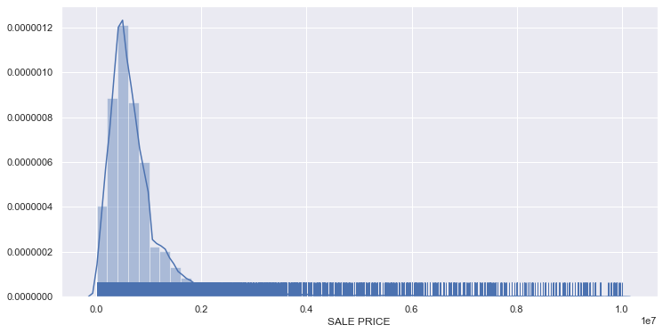

```python
plt.figure(figsize=(12,6))
sns.distplot(df2['SALE PRICE'], kde=True, bins=50, rug=True)
plt.show()
```

It seems that we can safely treat any sale price > 4,000,000 as an outlier. So let's remove them as well.

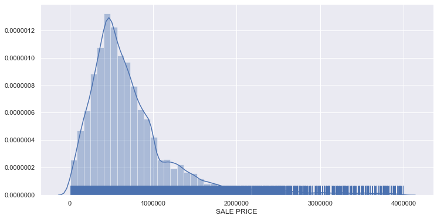

```python
df2= df2[(df2['SALE PRICE']<4000000)]
plt.figure(figsize=(12,6))
sns.distplot(df2['SALE PRICE'], kde=True, bins=50, rug=True)
plt.show()
```

### Year built:

```python
df2[df2['YEAR BUILT']==0]['YEAR BUILT'].count()
```

```
1434
```

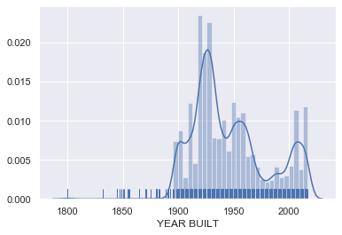

```python
df3=df2[df2['YEAR BUILT']!=0].copy()
sns.distplot(df3['YEAR BUILT'], bins=50, rug=True)
plt.show()
```

```python
len(df3)
```

```
33662
```

#### Total units

```python
df3[df3['TOTAL UNITS']==0]['TOTAL UNITS'].count()
```

```
3426
```

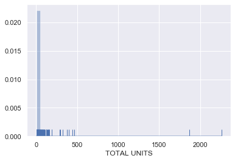

```python
df4=df3[df3['TOTAL UNITS']!=0].copy()
sns.distplot(df4['TOTAL UNITS'], bins=50, rug=True)
plt.show()
```

```python
df4.describe().T
```

|  | count | mean | std | min | 25% | 50% | 75% | max |
| --- | --- | --- | --- | --- | --- | --- | --- | --- |
| BLOCK | 30236.0 | 5418.821835 | 3753.775464 | 1.0 | 2395.0 | 4836.0 | 7677.0 | 16319.0 |
| LOT | 30236.0 | 185.704987 | 384.518819 | 1.0 | 22.0 | 44.0 | 83.0 | 3597.0 |
| RESIDENTIAL UNITS | 30236.0 | 1.970532 | 12.586963 | 0.0 | 1.0 | 1.0 | 2.0 | 1844.0 |
| COMMERCIAL UNITS | 30236.0 | 0.173039 | 13.034598 | 0.0 | 0.0 | 0.0 | 0.0 | 2261.0 |
| TOTAL UNITS | 30236.0 | 2.147804 | 18.198705 | 1.0 | 1.0 | 1.0 | 2.0 | 2261.0 |
| LAND SQUARE FEET | 30236.0 | 3133.582088 | 27966.319284 | 0.0 | 1816.5 | 2417.0 | 3500.0 | 4228300.0 |
| GROSS SQUARE FEET | 30236.0 | 2440.363276 | 23800.244758 | 0.0 | 1208.0 | 1680.0 | 2392.0 | 3750565.0 |
| SALE PRICE | 30236.0 | 793820.011146 | 594725.186839 | 10001.0 | 436000.0 | 630000.0 | 940000.0 | 3995000.0 |

```python
len(df4)
```

```
30236
```

## Finalizing the data set

```python
df4.info()
```

```
<class 'pandas.core.frame.DataFrame'>
Int64Index: 30236 entries, 3 to 84547
Data columns (total 21 columns):
BOROUGH                           30236 non-null category
NEIGHBORHOOD                      30236 non-null category
BUILDING CLASS CATEGORY           30236 non-null category
TAX CLASS AT PRESENT              30236 non-null category
BLOCK                             30236 non-null int64
LOT                               30236 non-null int64
BUILDING CLASS AT PRESENT         30236 non-null category
ADDRESS                           30236 non-null object
ZIP CODE                          30236 non-null category
RESIDENTIAL UNITS                 30236 non-null int64
COMMERCIAL UNITS                  30236 non-null int64
TOTAL UNITS                       30236 non-null int64
LAND SQUARE FEET                  30236 non-null float64
GROSS SQUARE FEET                 30236 non-null float64
YEAR BUILT                        30236 non-null category
TAX CLASS AT TIME OF SALE         30236 non-null category
BUILDING CLASS AT TIME OF SALE    30236 non-null category
SALE PRICE                        30236 non-null float64
SALE DATE                         30236 non-null datetime64[ns]
sale_year                         30236 non-null category
sale_month                        30236 non-null category
dtypes: category(11), datetime64[ns](1), float64(3), int64(5), object(1)
memory usage: 3.0+ MB
```

```python
df4.drop(['BLOCK','LOT','ADDRESS'], axis=1, inplace=True)
```

```python
#'1':'Manhattan', '2':'Bronx', '3': 'Brooklyn', '4':'Queens','5':'Staten Island'
df4['BOROUGH']= df4['BOROUGH'].map({1:'Manhattan', 2:'Bronx', 3: 'Brooklyn', 4:'Queens',5:'Staten Island'})
df4.head()
```

|  | BOROUGH | NEIGHBORHOOD | BUILDING CLASS CATEGORY | TAX CLASS AT PRESENT | BUILDING CLASS AT PRESENT | ZIP CODE | RESIDENTIAL UNITS | COMMERCIAL UNITS | TOTAL UNITS | LAND SQUARE FEET | GROSS SQUARE FEET | YEAR BUILT | TAX CLASS AT TIME OF SALE | BUILDING CLASS AT TIME OF SALE | SALE PRICE | SALE DATE | sale_year | sale_month |
| --- | --- | --- | --- | --- | --- | --- | --- | --- | --- | --- | --- | --- | --- | --- | --- | --- | --- | --- |
| 3 | Manhattan | ALPHABET CITY | 07 RENTALS - WALKUP APARTMENTS | 2B | C4 | 10009 | 10 | 0 | 10 | 2272.0 | 6794.0 | 1913 | 2 | C4 | 3936272.0 | 2016-09-23 | 2016 | 9 |
| 6 | Manhattan | ALPHABET CITY | 07 RENTALS - WALKUP APARTMENTS | 2B | C4 | 10009 | 8 | 0 | 8 | 1750.0 | 4226.0 | 1920 | 2 | C4 | 3192840.0 | 2016-09-23 | 2016 | 9 |
| 172 | Manhattan | ALPHABET CITY | 14 RENTALS - 4-10 UNIT | 2A | S3 | 10009 | 3 | 1 | 4 | 1520.0 | 3360.0 | 1910 | 2 | S3 | 3300000.0 | 2016-11-15 | 2016 | 11 |
| 195 | Manhattan | ALPHABET CITY | 22 STORE BUILDINGS | 4 | K4 | 10009 | 0 | 1 | 1 | 1218.0 | 3586.0 | 1899 | 4 | K4 | 3700000.0 | 2016-09-28 | 2016 | 9 |
| 222 | Manhattan | CHELSEA | 07 RENTALS - WALKUP APARTMENTS | 2B | C4 | 10011 | 9 | 0 | 9 | 1566.0 | 6330.0 | 1901 | 2 | C4 | 1583840.0 | 2017-08-31 | 2017 | 8 |

## Some other plots!

```python
df_bar =df4[['BOROUGH', 'SALE PRICE']].groupby(by='BOROUGH').mean().sort_values(by='SALE PRICE', ascending=True).reset_index()
df_bar
```

|  | BOROUGH | SALE PRICE |
| --- | --- | --- |
| 0 | Staten Island | 5.257797e+05 |
| 1 | Bronx | 5.581147e+05 |
| 2 | Queens | 7.079732e+05 |
| 3 | Brooklyn | 1.039752e+06 |
| 4 | Manhattan | 1.846523e+06 |

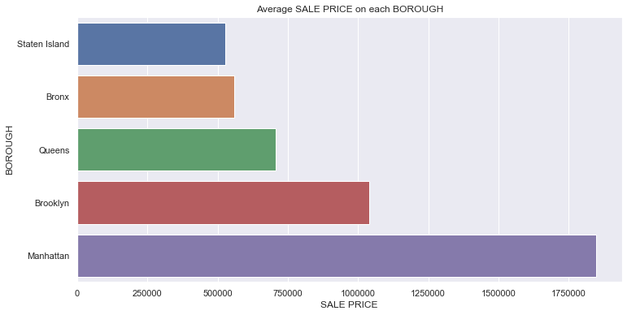

```python
plt.figure(figsize=(12,6))
sns.barplot(y = 'BOROUGH', x = 'SALE PRICE', data = df_bar )
plt.title('Average SALE PRICE on each BOROUGH')
plt.show()
```

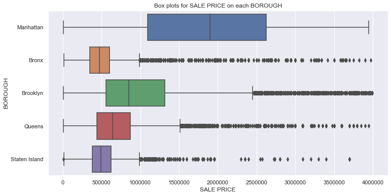

```python
plt.figure(figsize=(12,6))
sns.boxplot(y = 'BOROUGH', x = 'SALE PRICE', data = df4 )
plt.title('Box plots for SALE PRICE on each BOROUGH')
plt.show()
```

```python
df_bar=df4[['sale_month', 'SALE PRICE']].groupby(by='sale_month').count().sort_values(by='sale_month', ascending=True).reset_index()
df_bar.columns.values[1]='Sales_count'
df_bar
```

|  | sale_month | Sales_count |
| --- | --- | --- |
| 0 | 1 | 2432 |
| 1 | 2 | 2323 |
| 2 | 3 | 2782 |
| 3 | 4 | 2344 |
| 4 | 5 | 2565 |
| 5 | 6 | 2931 |
| 6 | 7 | 2328 |
| 7 | 8 | 1937 |
| 8 | 9 | 2807 |
| 9 | 10 | 2373 |
| 10 | 11 | 2545 |
| 11 | 12 | 2869 |

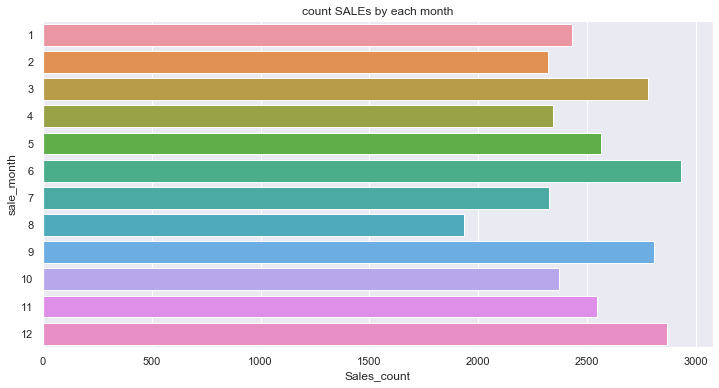

```python
plt.figure(figsize=(12,6))
sns.barplot(y = 'sale_month', x = 'Sales_count', data = df_bar )
plt.title('count SALEs by each month')
plt.show()
```

### Saving the final data set

```python
df4.to_csv('nyc-rolling-sales_clean.csv',index=False)
```